# Course-1: Python for Data Systems (Project): FoodHub Data Analysis

**Marks: 40**

## Project Overview:

### Context

The number of restaurants in New York is increasing day by day. Lots of students and busy professionals rely on those restaurants due to their hectic lifestyles. Online food delivery service is a great option for them. It provides them with good food from their favorite restaurants. A food aggregator company FoodHub offers access to multiple restaurants through a single smartphone app.

The app allows the restaurants to receive a direct online order from a customer. The app assigns a delivery person from the company to pick up the order after it is confirmed by the restaurant. The delivery person then uses the map to reach the restaurant and waits for the food package. Once the food package is handed over to the delivery person, he/she confirms the pick-up in the app and travels to the customer's location to deliver the food. The delivery person confirms the drop-off in the app after delivering the food package to the customer. The customer can rate the order in the app. The food aggregator earns money by collecting a fixed margin of the delivery order from the restaurants.

### Objective

The food aggregator company has stored the data of the different orders made by the registered customers in their online portal. They want to analyze the data to get a fair idea about the demand of different restaurants which will help them in enhancing their customer experience. Suppose you are hired as a Data Scientist in this company and the Data Science team has shared some of the key questions that need to be answered. Perform the data analysis to find answers to these questions that will help the company to improve the business.

### Data Dictionary

- order_id: Unique ID of the order
- customer_id: ID of the customer who ordered the food
- restaurant_name: Name of the restaurant
- cuisine_type: Cuisine ordered by the customer
- cost_of_the_order: Cost of the order
- day_of_the_week: Indicates whether the order is placed on a weekday or weekend (The weekday is from Monday to Friday and the weekend is Saturday and Sunday)
- rating: Rating given by the customer out of 5
- food_preparation_time: Time (in minutes) taken by the restaurant to prepare the food. This is calculated by taking the difference between the timestamps of the restaurant's order confirmation and the delivery person's pick-up confirmation.
- delivery_time: Time (in minutes) taken by the delivery person to deliver the food package. This is calculated by taking the difference between the timestamps of the delivery person's pick-up confirmation and drop-off information

## Descriptive Analysis

### Import the required libraries

```python
# import libraries for data manipulation
import numpy as np
import pandas as pd

# import libraries for data visualization
import matplotlib.pyplot as plt
import seaborn as sns
sns.set(color_codes=True) # adding background to the graphs

# import library to scrape the table from the webpage
from bs4 import BeautifulSoup
```

### Question 1: Write the code to scrape the table from the 'foodhub_order.html' and read the data. (0.5 mark)

```python
with open('foodhub_orders.html') as f:
    soup = BeautifulSoup(f, 'html.parser')

# Identify the column names for the future dataframe
column_titles = soup.find_all('th')
column_names = []
for col in column_titles:
    column_names.append(col.text)

# Now extract the data that is associated with each column from the tbody
combined_data = []
data = soup.find('tbody').find_all('tr')
for i in range(len(data)):
    data_lst = data[i].text.strip().split('\n')
    combined_data.append(data_lst)

# Create a pandas dataframe, initial view of the data
df = pd.DataFrame(combined_data, columns=column_names)

print('##### DataFrame Head ####')
print(df.head())
```

```
##### DataFrame Head ####
  order_id customer_id            restaurant_name cuisine_type  \
0  1477147      337525                    Hangawi       Korean
1  1477685      358141  Blue Ribbon Sushi Izakaya     Japanese
2  1477070       66393                Cafe Habana      Mexican
3  1477334      106968  Blue Ribbon Fried Chicken     American
4  1478249       76942           Dirty Bird to Go     American

  cost_of_the_order day_of_the_week     rating food_preparation_time  \
0             30.75         Weekend  Not given                    25
1             12.08         Weekend  Not given                    25
2             12.23         Weekday          5                    23
3              29.2         Weekend          3                    25
4             11.59         Weekday          4                    25

  delivery_time
0            20
1            23
2            28
3            15
4            24
```

#### Observations:

This data seems to be various orders from restaurants, of multiple cuisine types, throughout an unknown area. The data include order ids, customer ids, the name of the restaurant, type of cuisine, total cost of an order, the day of the week, a rating (sometimes not give or NaN), the preparation time for the order, and the delivery time.

### **Question 2:** Get the shape of the dataset (no. of rows and columns) in the form of a tuple (0.5 mark)

```python
print(f'The Shape of the DataFrame is {df.shape[0]} rows and {df.shape[1]} columns')
print('As a tuple: ', df.shape)
```

```
The Shape of the DataFrame is 1898 rows and 9 columns
As a tuple:  (1898, 9)
```

### Question 3: Use the info() to get a detailed description of the dataframe's metadata, and note your observations (0.5 mark)

```python
print(df.info())
```

```
<class 'pandas.core.frame.DataFrame'>
RangeIndex: 1898 entries, 0 to 1897
Data columns (total 9 columns):
 #   Column                 Non-Null Count  Dtype
---  ------                 --------------  -----
 0   order_id               1898 non-null   object
 1   customer_id            1898 non-null   object
 2   restaurant_name        1898 non-null   object
 3   cuisine_type           1898 non-null   object
 4   cost_of_the_order      1898 non-null   object
 5   day_of_the_week        1898 non-null   object
 6   rating                 1898 non-null   object
 7   food_preparation_time  1898 non-null   object
 8   delivery_time          1898 non-null   object
dtypes: object(9)
memory usage: 133.6+ KB
None
```

#### Observations:

The data are all read in as "object" data type. Some of these will need to be converted to numeric for our analysis. Although order id and customer id are numeric in nature they will likely remain object/string because that will make more sense in the analysis. Statistics will make little to no sense on this two fields as they're more categorical in nature. They're all non-null, however, further analysis will detemine if numeric values are filled with "not given" and need to be converted to NaN to make more effective analysis possible. Thus, filled or replaced if necessary/logical.

### Question 4: 'restaurant_name', 'cuisine_type', 'day_of_the_week' are object types. Convert the mentioned features to 'category' and write your observations (0.5 mark)

```python
df[['restaurant_name', 'cuisine_type', 'day_of_the_week' ]] = df[
    ['restaurant_name', 'cuisine_type', 'day_of_the_week' ]].astype('category')

df.info()
```

```
<class 'pandas.core.frame.DataFrame'>
RangeIndex: 1898 entries, 0 to 1897
Data columns (total 9 columns):
 #   Column                 Non-Null Count  Dtype
---  ------                 --------------  -----
 0   order_id               1898 non-null   object
 1   customer_id            1898 non-null   object
 2   restaurant_name        1898 non-null   category
 3   cuisine_type           1898 non-null   category
 4   cost_of_the_order      1898 non-null   object
 5   day_of_the_week        1898 non-null   category
 6   rating                 1898 non-null   object
 7   food_preparation_time  1898 non-null   object
 8   delivery_time          1898 non-null   object
dtypes: category(3), object(6)
memory usage: 102.7+ KB
```

#### Observations:

The desired fields were converted to category with no issues. We will look further into the unique values and statistics behind them later in the analysis. There are 4 numeric columns that need to be converted prior to any summary statistics or continued analysis.

### **Question 5:** Find the summary statistics of the numeric columns and write your observations (0.5 mark)

```python
# Convert the "numeric" columns that were read in as string with the beautifulsoup logic
num_cols = ['cost_of_the_order', 'rating', 'food_preparation_time', 'delivery_time']

for col in num_cols:
    df[col] = pd.to_numeric(
        df[col], errors='coerce')

# Validate, and get an idea of nan
df.info()
```

```
<class 'pandas.core.frame.DataFrame'>
RangeIndex: 1898 entries, 0 to 1897
Data columns (total 9 columns):
 #   Column                 Non-Null Count  Dtype
---  ------                 --------------  -----
 0   order_id               1898 non-null   object
 1   customer_id            1898 non-null   object
 2   restaurant_name        1898 non-null   category
 3   cuisine_type           1898 non-null   category
 4   cost_of_the_order      1898 non-null   float64
 5   day_of_the_week        1898 non-null   category
 6   rating                 1162 non-null   float64
 7   food_preparation_time  1898 non-null   int64
 8   delivery_time          1898 non-null   int64
dtypes: category(3), float64(2), int64(2), object(2)
memory usage: 102.7+ KB
```

### Research the ratings field to seek solutions for nan values

```python
raw_data = df.copy()
# See if the restaurants have other columns with non-nan that we can replace by average
df_test = df.groupby('restaurant_name')['rating'].mean().reset_index().sort_values('rating')
# From this I've learned that there are restaurants that have all nan regarding ratings, non with a zero avg otherwise
df_zero_avg = df_test[df_test.rating==0]
# Replace nan with restaurant avg to corret as many as possible
df["rating"] = df.groupby("restaurant_name")['rating'].transform(lambda x: x.fillna(x.mean()))

df.describe()
```

|  | cost_of_the_order | rating | food_preparation_time | delivery_time |
| --- | --- | --- | --- | --- |
| count | 1898.000000 | 1868.000000 | 1898.000000 | 1898.000000 |
| mean | 16.498851 | 4.349154 | 27.371970 | 24.161749 |
| std | 7.483812 | 0.610783 | 4.632481 | 4.972637 |
| min | 4.470000 | 3.000000 | 20.000000 | 15.000000 |
| 25% | 12.080000 | 4.000000 | 23.000000 | 20.000000 |
| 50% | 14.140000 | 4.328125 | 27.000000 | 25.000000 |
| 75% | 22.297500 | 5.000000 | 31.000000 | 28.000000 |
| max | 35.410000 | 5.000000 | 35.000000 | 33.000000 |

#### Observations:

- Cost: The average cost of an order is near \$16.50, with a standard deviation of around \\$7.50
- Rating: The restaurants are generally rated fairly high on a scale of 1 to 5. An Average of 4.35 out of 5, with a minimum of 3. 75% of the orders are rated greater than or equal to 4. Generous patrons, or good list of restaurants.
- Preperation time: On average about 27.4 minutes to prepare. Within a range of 20 minutes to 35 minutes.
- Delivery time: The average delivery time is about 24 minutes, with a range of 15 minutes to 33 minutes.

This is good information, also suggesting that there aren't any extreme outliers in this data.

### **Question 6:** How many orders are not rated? (0.5 mark)

```python
orders_not_rated = raw_data.loc[raw_data['rating'].isnull(), :].shape[0]
print(f"The number of orders that weren't ranked is: {orders_not_rated}")

after_averaging = df.loc[df['rating'].isnull(), :].shape[0]
print(f"The number of orders that weren't ranked after averaging by restaurant is: {after_averaging}")
```

```
The number of orders that weren't ranked is: 736
The number of orders that weren't ranked after averaging by restaurant is: 30
```

## Exploratory Data Analysis (EDA)

### **Question 7:** Explore all the variables individually and provide your observations - look for count, unique values, distributions (5 marks)

```python
# How many unique restaurants exist in the data?
unique_restaurants = df['restaurant_name'].nunique()
print(f'The number of different restaurant options in this dataset is: {unique_restaurants}')
# How many customers in the data set?
count_of_customers = df['customer_id'].nunique()
print(f'The number of different customers in this dataset is: {count_of_customers}')
# How many different cuisine options?
different_cuisines = df['cuisine_type'].nunique()
print(f'The number of different cuisine options are in this dataset is: {different_cuisines}')
```

```
The number of different restaurant options in this dataset is: 178
The number of different customers in this dataset is: 1200
The number of different cuisine options are in this dataset is: 14
```

```
The count of orders by weekday or weekend
```

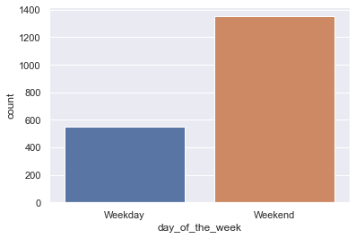

```python
# Plotting counts with different features
print('The count of orders by weekday or weekend')
sns.countplot(data = df, x='day_of_the_week');
```

```
Count of orders by cuisine type
```

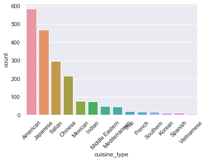

```python
print('Count of orders by cuisine type')
sns.countplot(data = df, x='cuisine_type', order=df['cuisine_type'].value_counts().index)
plt.xticks(rotation=45)
plt.savefig('./cuisine_popularity.png');
```

```
Count of orders by restaurant name (Top 15)
```

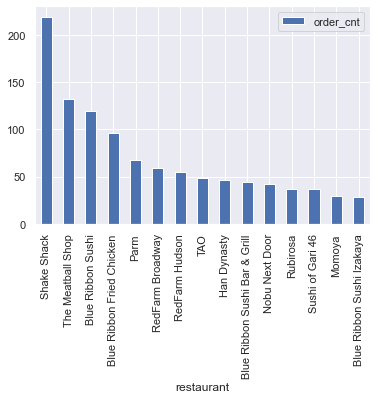

```python
print('Count of orders by restaurant name (Top 15)')
df_restaurant_cnt=df['restaurant_name'].value_counts().reset_index()
df_restaurant_cnt.rename(columns={'index':'restaurant', 'restaurant_name':'order_cnt'}, inplace=True)
df_restaurant_cnt = df_restaurant_cnt.head(15)
df_restaurant_cnt.plot(kind='bar', x='restaurant')
plt.savefig('./top15_restaurants.png');
```

```
A look at cost
```

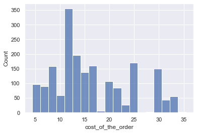

```python
# Histogram viz of the numeric columns price, ratings, prep time, and delivery time
print('A look at cost')
sns.histplot(df.cost_of_the_order);
```

```
A look at ratings
```

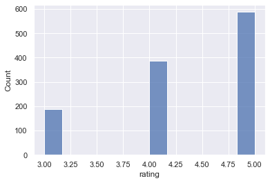

```python
print('A look at ratings')
sns.histplot(raw_data.rating);
```

```
A look at the preparation time
```

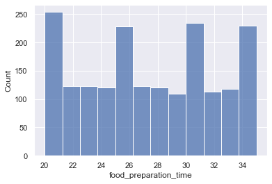

```python
print('A look at the preparation time')
sns.histplot(df.food_preparation_time);
```

```
A look at delivery times
```

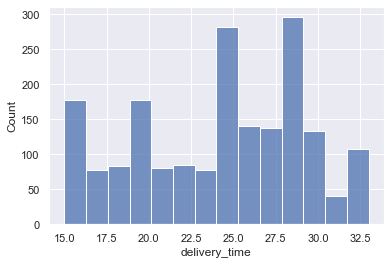

```python
print('A look at delivery times')
sns.histplot(df.delivery_time);
```

### **Question 8**: Which are the top 5 restaurants in terms of the number of orders received? (1 mark)

```python
# Ensure that oder numbers are unique
print(f"The number of unique order ids {df['order_id'].nunique()} and the number of orders {df.shape[0]}")
```

```
The number of unique order ids 1898 and the number of orders 1898
```

```python
top_5_visited = df.groupby('restaurant_name')['order_id'].count().reset_index(
    ).sort_values('order_id', ascending=False).head()
top_5_visited = top_5_visited['restaurant_name'].to_list()

print('The Top 5 Restaurants Ordered From In The Data: ')
for i in top_5_visited:
    print(i)
```

```
The Top 5 Restaurants Ordered From In The Data:
Shake Shack
The Meatball Shop
Blue Ribbon Sushi
Blue Ribbon Fried Chicken
Parm
```

#### Observations:

The **top 5 restaurants** in terms of number of orders in this data set are the following:  
**First:** Shake Shack  
**Second:** The Meatball Shop  
**Third:** Blue Ribbon Sushi  
**Forth:** Blue Ribbon Fried Chicken  
**Fifth:** Parm

### Question 9: Find the most popular cuisine on weekends. (1 mark)

```python
# Verify the unique values in "day_of_the_week" for masking
unique_days = df['day_of_the_week'].unique()
# print(unique_days)
# Simply Weekend or Weekday
weekend_popular = df[df['day_of_the_week']=='Weekend'].groupby(
    'cuisine_type')['order_id'].count().reset_index().sort_values('order_id', ascending=False)

weekend_popular.rename(columns={'order_id': 'order_count'}, inplace=True)

print(f"The most popular cuisine on the weekend is: {weekend_popular['cuisine_type'][0]}")
weekend_popular
```

```
The most popular cuisine on the weekend is: American
```

|  | cuisine_type | order_count |
| --- | --- | --- |
| 0 | American | 415 |
| 5 | Japanese | 335 |
| 4 | Italian | 207 |
| 1 | Chinese | 163 |
| 8 | Mexican | 53 |
| 3 | Indian | 49 |
| 7 | Mediterranean | 32 |
| 9 | Middle Eastern | 32 |
| 12 | Thai | 15 |
| 2 | French | 13 |
| 6 | Korean | 11 |
| 10 | Southern | 11 |
| 11 | Spanish | 11 |
| 13 | Vietnamese | 4 |

#### Observations:

American cuisine is visited considerably more than other options on the weekend at 415 orders. Japanese coming in second with 335 orders. Likely, these restaurants are in the USA and many of them are classified as "American" simply by being in the United States - assuming that they also offer additional cuisine types on the menu. I think it is notibale that Japanese cuisine comes in 2nd, well above other options excluding American.

### Question 10: Find the number of total orders where the cost is above 20 dollars. What is the percentage of such orders in the dataset? (1 mark)

```python
orders_gt_20 = df[df['cost_of_the_order']>20].shape[0]
total_orders = df.shape[0]

print(f"The total number of orders greater than $20 is {orders_gt_20} out of {total_orders}")
print(f"That is roughly {round((orders_gt_20/total_orders)*100)}% of the orders")
```

```
The total number of orders greater than $20 is 555 out of 1898
That is roughly 29% of the orders
```

#### Observations:

Roughly 29% of the orders are greater than \$20. This agrees with the prior summary statistics suggesting that \\$22.30 was in the 75th percentile. Couple dollars less includes a additional observations - 71st percentile.

### Question 11: Find the mean delivery time based on this dataset. (1 mark)

```python
# The mean delivery time
mean_delivery = round(df['delivery_time'].mean(), 2)
mean_delivery
```

```
24.16
```

#### Observations:

The mean delivery time for the restaurants in this dataset is 24.16 minutes, as we saw in the summary statistics.

### Question 12: Suppose the company has decided to give a free coupon of 15 dollars to the customer who has spent the maximum amount on a single order. Write the code to find the ID of the customer along with the order details. (1 mark)

```python
# Identify the customer with the max order value, and the order details
max_order = df.iloc[[df['cost_of_the_order'].idxmax(axis=0)]]
max_order_cols = max_order.columns

for i in range(len(max_order_cols)):
    print(max_order_cols[i], max_order.loc[[573], [max_order_cols[i]]].values[0])
```

```
order_id ['1477814']
customer_id ['62359']
restaurant_name ['Pylos']
cuisine_type ['Mediterranean']
cost_of_the_order [35.41]
day_of_the_week ['Weekday']
rating [4.]
food_preparation_time [21]
delivery_time [29]
```

#### Observations:

#### The customer id: 62359

#### The order details:

**Order id:** 1477814  
**Restaurant name:** Pylos  
**Cuisine type:** Mediterranean  
**Cost:** \$35.41  
**Weekend or Weekday?:** Weekday  
**Rating:** 4.0  
**Preparation time:** 21 minutes  
**Delivery time:** 29 minutes

### Question 13: Perform bivariate/multivariate analysis to explore relationships between the variables in the dataset. (7 marks)

```
A pairplot of all numeric fields
```

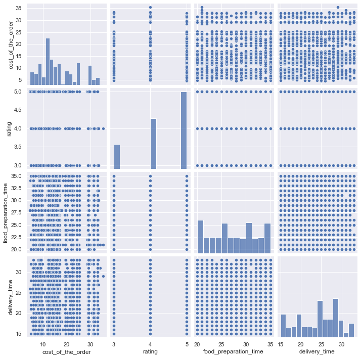

```python
print('A pairplot of all numeric fields')
sns.pairplot(raw_data);
```

```
A jointplot view of the restaurant's rating vs price
```

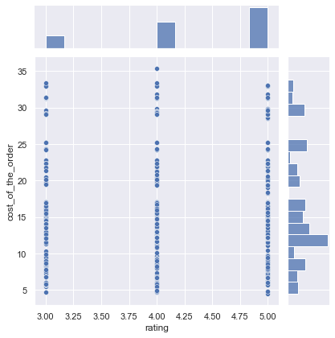

```python
print("A jointplot view of the restaurant's rating vs price")
sns.jointplot(data=raw_data, x='rating', y='cost_of_the_order');
```

```
A jointplot view of the restaurant's rating vs delivery time
```

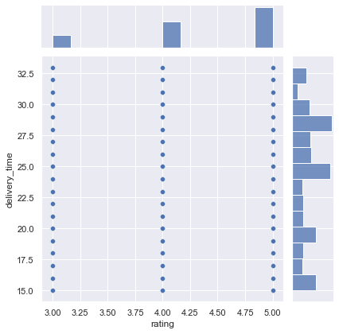

```python
print("A jointplot view of the restaurant's rating vs delivery time")
sns.jointplot(data=raw_data, x='rating', y='delivery_time');
```

```
A box plot view of the restaurant's rating vs delivery time
```

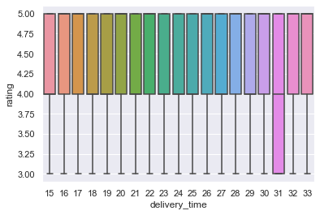

```python
print("A box plot view of the restaurant's rating vs delivery time")
sns.boxplot(data=raw_data, x='delivery_time', y='rating');
```

```
A box plot view of the Weekend/Weekday vs Price
```

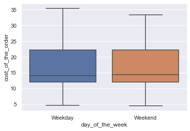

```python
print("A box plot view of the Weekend/Weekday vs Price")
sns.boxplot(data=df, x='day_of_the_week', y='cost_of_the_order');
```

```
A box plot view of the Weekend/Weekday vs Delivery Time
```

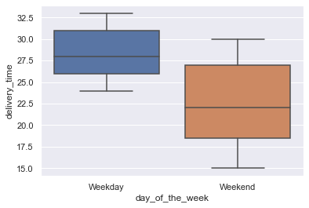

```python
print("A box plot view of the Weekend/Weekday vs Delivery Time")
sns.boxplot(data=df, x='day_of_the_week', y='delivery_time')
plt.savefig('./boxplot_dayVtime.png');
```

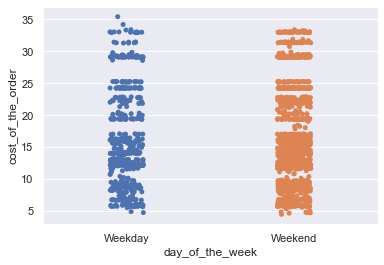

```python
sns.stripplot(data=df, x='day_of_the_week', y='cost_of_the_order', jitter=True)
plt.savefig('./dayVcost.png');
```

### Question 14: Suppose the company wants to provide a promotional offer in the advertisement of the restaurants. The condition to get the offer is that the restaurants must have a rating count of more than 50 and the average rating should be greater than 4. Write the code to find the restaurants fulfilling the criteria to get the promotional offer. (2 marks)

```python
# Generate a secondary dataframe with the count of reviews, and average - grouped by restaurant
# Utilzing the raw_data set because it doesn't have the fill na logic included
promotional_df = raw_data[raw_data['rating'].notnull()].groupby('restaurant_name').agg(
    {'order_id': 'count', 'rating': 'mean'}).reset_index()
# Rename the columns to make logical sense
promotional_df.rename(columns={'order_id':'order_cnt', 'rating':'avg_rating'}, inplace=True)
# Filter the data for the requested criteria
promotional_df = promotional_df[(promotional_df['order_cnt']>50)&(promotional_df['avg_rating']>4)]
# Sort the values for "ranking"
promotional_df.sort_values(['avg_rating', 'order_cnt'], ascending=False, inplace=True)
promotional_df['restaurant_name'].to_list()
```

```
['The Meatball Shop',
 'Blue Ribbon Fried Chicken',
 'Shake Shack',
 'Blue Ribbon Sushi']
```

### Question 15: Suppose the company charges the restaurant 25% on the orders having cost greater than 20 dollars and 15% on the orders having cost greater than 5 dollars. Write the code to find the net revenue generated on all the orders given in the dataset. (2 marks)

```python
# Delivery charge calculation for company FoodHub
# Although not specified for orders less than or equal to $5, the revenue is assumed $0 and applied for those 9 orders
conditions = [df['cost_of_the_order']>20, df['cost_of_the_order']>5, df['cost_of_the_order']<5]
values = [df['cost_of_the_order']*.25, df['cost_of_the_order']*.15, 0]
df['company_revenue'] = np.select(conditions, values)
# Calculate net revenue
revenue = round(df['company_revenue'].sum(), 2)

print(f'The revenue for FoodHub in the dataset is: ${revenue}')
```

```
The revenue for FoodHub in the dataset is: $6166.3
```

#### Observations:

Under these conditions the revenue realized by FoodHub in this dataset is \$6,166.30 <br> However, this comes with a disclaimer that the 9 orders sub-\\$5.01 were assumed to be \$0 revenue as it wasn't specified in the conditions.

I recommend setting a minimum delivery charge to prevent these occurrences.

### Question 16: Suppose the company wants to analyze the total time required to deliver the food. Write the code to find out the percentage of orders that have more than 60 minutes of total delivery time. (2 marks)

Note: The total delivery time is the summation of the food preparation time and delivery time.

```python
# Delivery time analysis - calculate total delivery time field
df['total_delivery_time'] = df['food_preparation_time'] + df['delivery_time']
# Filter and count
cnt_60m_delivery = df[df['total_delivery_time']>60].shape[0]
pct_60m_delivery = round((cnt_60m_delivery/df.shape[0])*100, 2)

print(cnt_60m_delivery, pct_60m_delivery)
```

```
200 10.54
```

#### Observations:

There are 200 orders that exceeded 60 minutes total delivery time. That is roughly 10.5% of the orders in this dataset. Important note is that 45 orders were exactly 60 minutes. Looking to bring that to attention to ensure that we didn't want to note orders that were greater than or equal to 60 minutes. That difference would increase the figure to just under 13% of the orders.

### Question 17: Suppose the company wants to analyze the delivery time of the orders on weekdays and weekends. Write the code to find the mean delivery time on weekdays and weekends. Write your observations on the results. (2 marks)

```python
# Looking at the prep, delivery and total delivery times by "day of the week"
delivery_by_day = df.groupby('day_of_the_week')[
    ['food_preparation_time', 'delivery_time', 'total_delivery_time']].agg('mean').round(2).reset_index()

delivery_by_day
```

|  | day_of_the_week | food_preparation_time | delivery_time | total_delivery_time |
| --- | --- | --- | --- | --- |
| 0 | Weekday | 27.21 | 28.34 | 55.55 |
| 1 | Weekend | 27.44 | 22.47 | 49.91 |

```python
delivery_cnt_by_day = df.groupby('day_of_the_week')['order_id'].count().reset_index()
delivery_cnt_by_day
```

|  | day_of_the_week | order_id |
| --- | --- | --- |
| 0 | Weekday | 547 |
| 1 | Weekend | 1351 |

```python
delivery_sum_by_day = df.groupby('day_of_the_week')['delivery_time'].sum().reset_index()
delivery_sum_by_day
```

|  | day_of_the_week | delivery_time |
| --- | --- | --- |
| 0 | Weekday | 15502 |
| 1 | Weekend | 30357 |

#### Observations:

The food preparation time is relatively consistent across both weekdays and weekends. The delivery time does increase by about 26% on weekdays. Likely due to local traffic increases. There are many more weekend orders than weekday orders so it is hard to believe that it is due to order volume.

### Conclusion and Recommendations

### **Question 18:** Write the conclusions and business recommendations derived from the analysis. (3 marks)

#### Conclusion:

We need to consider a minimum fee or something to make up for the orders less than $5. Current model seems to deliver those meals for no charge.

Lastly, I recommend that we consider an upcharge for weekday deliverys. We have much fewer orders on the weekdays, but order delivery time has a 26\% increase. I assume this is due to traffic during busier times of the day. Possibly upcharge during the primetime, and reduce costs outside of that time, but near, to help people receive their meals faster, and spread our business out over a greater time period.